# Partie Data Quality

## Etape 1 : Exploration

```python
import pandas as pd

df = pd.read_csv("Reviews.csv")

df
```

|  | Id | ProductId | UserId | ProfileName | HelpfulnessNumerator | HelpfulnessDenominator | Score | Time | Summary | Text |
| --- | --- | --- | --- | --- | --- | --- | --- | --- | --- | --- |
| 0 | 1 | B001E4KFG0 | A3SGXH7AUHU8GW | delmartian | 1 | 1 | 5 | 1303862400 | Good Quality Dog Food | I have bought several of the Vitality canned d... |
| 1 | 2 | B00813GRG4 | A1D87F6ZCVE5NK | dll pa | 0 | 0 | 1 | 1346976000 | Not as Advertised | Product arrived labeled as Jumbo Salted Peanut... |
| 2 | 3 | B000LQOCH0 | ABXLMWJIXXAIN | Natalia Corres "Natalia Corres" | 1 | 1 | 4 | 1219017600 | "Delight" says it all | This is a confection that has been around a fe... |
| 3 | 4 | B000UA0QIQ | A395BORC6FGVXV | Karl | 3 | 3 | 2 | 1307923200 | Cough Medicine | If you are looking for the secret ingredient i... |
| 4 | 5 | B006K2ZZ7K | A1UQRSCLF8GW1T | Michael D. Bigham "M. Wassir" | 0 | 0 | 5 | 1350777600 | Great taffy | Great taffy at a great price. There was a wid... |
| ... | ... | ... | ... | ... | ... | ... | ... | ... | ... | ... |
| 568449 | 568450 | B001EO7N10 | A28KG5XORO54AY | Lettie D. Carter | 0 | 0 | 5 | 1299628800 | Will not do without | Great for sesame chicken..this is a good if no... |
| 568450 | 568451 | B003S1WTCU | A3I8AFVPEE8KI5 | R. Sawyer | 0 | 0 | 2 | 1331251200 | disappointed | I'm disappointed with the flavor. The chocolat... |
| 568451 | 568452 | B004I613EE | A121AA1GQV751Z | pksd "pk_007" | 2 | 2 | 5 | 1329782400 | Perfect for our maltipoo | These stars are small, so you can give 10-15 o... |
| 568452 | 568453 | B004I613EE | A3IBEVCTXKNOH | Kathy A. Welch "katwel" | 1 | 1 | 5 | 1331596800 | Favorite Training and reward treat | These are the BEST treats for training and rew... |
| 568453 | 568454 | B001LR2CU2 | A3LGQPJCZVL9UC | srfell17 | 0 | 0 | 5 | 1338422400 | Great Honey | I am very satisfied ,product is as advertised,... |

568454 rows × 10 columns

```python
df.describe()
```

|  | Id | HelpfulnessNumerator | HelpfulnessDenominator | Score | Time |
| --- | --- | --- | --- | --- | --- |
| count | 568454.000000 | 568454.000000 | 568454.00000 | 568454.000000 | 5.684540e+05 |
| mean | 284227.500000 | 1.743817 | 2.22881 | 4.183199 | 1.296257e+09 |
| std | 164098.679298 | 7.636513 | 8.28974 | 1.310436 | 4.804331e+07 |
| min | 1.000000 | 0.000000 | 0.00000 | 1.000000 | 9.393408e+08 |
| 25% | 142114.250000 | 0.000000 | 0.00000 | 4.000000 | 1.271290e+09 |
| 50% | 284227.500000 | 0.000000 | 1.00000 | 5.000000 | 1.311120e+09 |
| 75% | 426340.750000 | 2.000000 | 2.00000 | 5.000000 | 1.332720e+09 |
| max | 568454.000000 | 866.000000 | 923.00000 | 5.000000 | 1.351210e+09 |

- *Quel est le transfer learning et comment sera-t-il utile pour prédire les commentaires de votre client ?*

  Le transfer learning réutilise un modèle linguistique pré-entraîné pour extraire des informations des commentaires clients sur Amazon, optimisant ainsi la prédiction de satisfaction et économisant des ressources d'entraînement.
- *Quelle est votre variable d’entrée ? Dans quelle mesure pouvez-vous intégrer la variable summary dans la variable cible ?*

  La variable d'entrée serait probablement la colonne "Text" du dataset, qui contient le texte complet des commentaires des clients. La variable cible serait la colonne "Score", qui représente le niveau de satisfaction du client. La variable "Summary" pourrait être intégrée à la variable d'entrée en concaténant son contenu avec le texte complet du commentaire. Cela pourrait potentiellement fournir plus de contexte au modèle pour prédire la satisfaction du client.

```python
print(df.dtypes)
print(df.loc[29940])
df['Text'] = df['Text'].astype(str)
```

```
Id                         int64
ProductId                 object
UserId                    object
ProfileName               object
HelpfulnessNumerator       int64
HelpfulnessDenominator     int64
Score                      int64
Time                       int64
Summary                   object
Text                      object
dtype: object
Id                                                                    29941
ProductId                                                        B001I8EVZI
UserId                                                       A18ZDK4TXMIV17
ProfileName                                                     Chris Carty
HelpfulnessNumerator                                                      2
HelpfulnessDenominator                                                    2
Score                                                                     5
Time                                                             1273449600
Summary                                                      Goooood Coffee
Text                      I live overseas, and the taste of good ol amer...
Name: 29940, dtype: object
```

```python
# Vérifier s'il y a des valeurs manquantes dans les colonnes Text et Summary
missing_text = df['Text'].isnull().sum()
missing_summary = df['Summary'].isnull().sum()

# Vérifier s'il y a des commentaires vides ou sans score
empty_comments = df[df['Text'].str.strip().eq('')].shape[0]
missing_score = df['Score'].isnull().sum()

print("Nombre de lignes sans texte :", missing_text)
print("Nombre de lignes sans résumé :", missing_summary)
print("Nombre de commentaires vides :", empty_comments)
print("Nombre de commentaires sans score :", missing_score)
```

```
Nombre de lignes sans texte : 0
Nombre de lignes sans résumé : 27
Nombre de commentaires vides : 0
Nombre de commentaires sans score : 0
```

```python
df.dropna()
```

|  | Id | ProductId | UserId | ProfileName | HelpfulnessNumerator | HelpfulnessDenominator | Score | Time | Summary | Text |
| --- | --- | --- | --- | --- | --- | --- | --- | --- | --- | --- |
| 0 | 1 | B001E4KFG0 | A3SGXH7AUHU8GW | delmartian | 1 | 1 | 5 | 1303862400 | Good Quality Dog Food | I have bought several of the Vitality canned d... |
| 1 | 2 | B00813GRG4 | A1D87F6ZCVE5NK | dll pa | 0 | 0 | 1 | 1346976000 | Not as Advertised | Product arrived labeled as Jumbo Salted Peanut... |
| 2 | 3 | B000LQOCH0 | ABXLMWJIXXAIN | Natalia Corres "Natalia Corres" | 1 | 1 | 4 | 1219017600 | "Delight" says it all | This is a confection that has been around a fe... |
| 3 | 4 | B000UA0QIQ | A395BORC6FGVXV | Karl | 3 | 3 | 2 | 1307923200 | Cough Medicine | If you are looking for the secret ingredient i... |
| 4 | 5 | B006K2ZZ7K | A1UQRSCLF8GW1T | Michael D. Bigham "M. Wassir" | 0 | 0 | 5 | 1350777600 | Great taffy | Great taffy at a great price. There was a wid... |
| ... | ... | ... | ... | ... | ... | ... | ... | ... | ... | ... |
| 568449 | 568450 | B001EO7N10 | A28KG5XORO54AY | Lettie D. Carter | 0 | 0 | 5 | 1299628800 | Will not do without | Great for sesame chicken..this is a good if no... |
| 568450 | 568451 | B003S1WTCU | A3I8AFVPEE8KI5 | R. Sawyer | 0 | 0 | 2 | 1331251200 | disappointed | I'm disappointed with the flavor. The chocolat... |
| 568451 | 568452 | B004I613EE | A121AA1GQV751Z | pksd "pk_007" | 2 | 2 | 5 | 1329782400 | Perfect for our maltipoo | These stars are small, so you can give 10-15 o... |
| 568452 | 568453 | B004I613EE | A3IBEVCTXKNOH | Kathy A. Welch "katwel" | 1 | 1 | 5 | 1331596800 | Favorite Training and reward treat | These are the BEST treats for training and rew... |
| 568453 | 568454 | B001LR2CU2 | A3LGQPJCZVL9UC | srfell17 | 0 | 0 | 5 | 1338422400 | Great Honey | I am very satisfied ,product is as advertised,... |

568411 rows × 10 columns

```python
from collections import Counter

# Tokenisation des mots dans le texte
all_words = ' '.join(df['Text']).split()
word_counts = Counter(all_words)

# Affichage des 20 mots les plus fréquents dans un tableau
word_counts_df = pd.DataFrame(word_counts.most_common(20), columns=['Word', 'Frequency'])
print(word_counts_df)
```

```
    Word  Frequency
0    the    1628045
1      I    1388076
2    and    1228666
3      a    1163164
4     to     992367
5     of     789652
6     is     714264
7     it     631252
8    for     519983
9     in     512394
10  this     488313
11  that     400467
12    my     364021
13  with     336250
14  have     335286
15   but     324932
16   are     310933
17   was     307861
18   not     285094
19   you     280382
```

- Un stopword est un mot très courant dans un langage naturel qui est souvent filtré lors du traitement automatique du langage naturel (NLP) car il apporte peu de valeur sémantique à l'analyse. Ces mots incluent des articles, des prépositions, des conjonctions et d'autres termes fréquents tels que "le", "de", "et", "à", etc. Ils sont souvent omis lors de tâches comme l'indexation ou la recherche de texte pour améliorer l'efficacité et la pertinence des résultats.

```python
pip install wordcloud
```

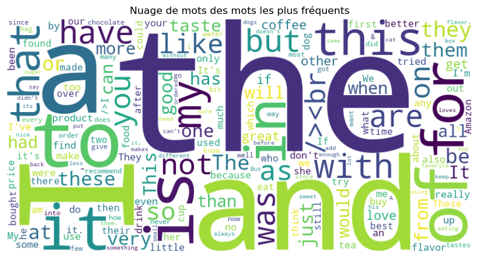

```python
import matplotlib.pyplot as plt
from wordcloud import WordCloud

# Création du nuage de mots avec la police par défaut de Matplotlib
wordcloud = WordCloud(width=800, height=400, background_color='white')

# Génération du nuage de mots
wordcloud.generate_from_frequencies(word_counts)

# Affichage du nuage de mots
plt.figure(figsize=(10, 5))
plt.imshow(wordcloud, interpolation='bilinear')
plt.axis('off')
plt.title('Nuage de mots des mots les plus fréquents')
plt.show()
```

- *Trouvez vous les chiffres et la ponctuation importants pour distinguer entre un commentaire positif ou négatif ?*

  L'importance des chiffres et de la ponctuation pour la classification des commentaires varie selon le contexte et la tâche. Les chiffres peuvent être pertinents pour identifier des aspects spécifiques ou des évaluations numériques, tandis que la ponctuation donne des indices sur le ton et l'émotion. L'inclusion de ces éléments dans les modèles de classification dépend du domaine et nécessite une exploration pour évaluer leur impact sur la prédiction du sentiment des commentaires.
- *Regardez les mots avec la même racine. Comment pouvons nous les regrouper ? Définir la lemmatisation.*

  Les mots avec la même racine peuvent être regroupés en utilisant une technique appelée lemmatisation. La lemmatisation est le processus de réduction des mots à leur forme de base ou de dictionnaire, appelée lemmes. Par exemple, les mots "manger", "mangeant", "mangé" sont tous ramenés à leur lemme "manger". Cette technique permet de regrouper les mots apparentés, facilitant ainsi l'analyse du texte en réduisant la diversité des formes de mots à traiter.

## Etape 2 : Nettoyage

```python
pip install nltk
```

```python
import nltk
from nltk.corpus import stopwords
from nltk.tokenize import word_tokenize

# Télécharger les ressources nécessaires pour NLTK
nltk.download('stopwords')
nltk.download('punkt')

# Liste des stopwords en anglais
stop_words = set(stopwords.words('english'))

# Fonction pour supprimer les stopwords d'une phrase
def remove_stopwords(text):
    words = word_tokenize(text)
    filtered_words = [word for word in words if word.lower() not in stop_words]
    return ' '.join(filtered_words)

# Appliquer la fonction remove_stopwords à la colonne 'Text' de votre DataFrame
df['Text'] = df['Text'].apply(remove_stopwords)

# Afficher les premières lignes du DataFrame après la suppression des stopwords
print(df.head())
```

```
   Id   ProductId          UserId                      ProfileName  \
0   1  B001E4KFG0  A3SGXH7AUHU8GW                       delmartian
1   2  B00813GRG4  A1D87F6ZCVE5NK                           dll pa
2   3  B000LQOCH0   ABXLMWJIXXAIN  Natalia Corres "Natalia Corres"
3   4  B000UA0QIQ  A395BORC6FGVXV                             Karl
4   5  B006K2ZZ7K  A1UQRSCLF8GW1T    Michael D. Bigham "M. Wassir"

   HelpfulnessNumerator  HelpfulnessDenominator  Score        Time  \
0                     1                       1      5  1303862400
1                     0                       0      1  1346976000
2                     1                       1      4  1219017600
3                     3                       3      2  1307923200
4                     0                       0      5  1350777600

                 Summary                                               Text
0  Good Quality Dog Food  bought several Vitality canned dog food produc...
1      Not as Advertised  Product arrived labeled Jumbo Salted Peanuts ....
2  "Delight" says it all  confection around centuries . light , pillowy ...
3         Cough Medicine  looking secret ingredient Robitussin believe f...
4            Great taffy  Great taffy great price . wide assortment yumm...
```

```python
import re

def remove_punctuation_and_digits(text):
    # Supprimer la ponctuation
    text_without_punctuation = re.sub(r'[^\w\s]', '', text)

    # Supprimer les chiffres
    text_without_digits = re.sub(r'\d', '', text_without_punctuation)

    return text_without_digits

# Appliquer la fonction de nettoyage aux commentaires
df['Text'] = df['Text'].apply(remove_punctuation_and_digits)

# Afficher les premières lignes du DataFrame après la suppression des chiffres et ponctuations
print(df.head())
```

```
   Id   ProductId          UserId                      ProfileName  \
0   1  B001E4KFG0  A3SGXH7AUHU8GW                       delmartian
1   2  B00813GRG4  A1D87F6ZCVE5NK                           dll pa
2   3  B000LQOCH0   ABXLMWJIXXAIN  Natalia Corres "Natalia Corres"
3   4  B000UA0QIQ  A395BORC6FGVXV                             Karl
4   5  B006K2ZZ7K  A1UQRSCLF8GW1T    Michael D. Bigham "M. Wassir"

   HelpfulnessNumerator  HelpfulnessDenominator  Score        Time  \
0                     1                       1      5  1303862400
1                     0                       0      1  1346976000
2                     1                       1      4  1219017600
3                     3                       3      2  1307923200
4                     0                       0      5  1350777600

                 Summary                                               Text
0  Good Quality Dog Food  bought several Vitality canned dog food produc...
1      Not as Advertised  Product arrived labeled Jumbo Salted Peanuts  ...
2  "Delight" says it all  confection around centuries  light  pillowy ci...
3         Cough Medicine  looking secret ingredient Robitussin believe f...
4            Great taffy  Great taffy great price  wide assortment yummy...
```

```python
import nltk
from nltk.stem import WordNetLemmatizer
from nltk.tokenize import word_tokenize

nltk.download('omw-1.4')
nltk.download('punkt')
nltk.download('wordnet')

# Créer un lemmatiseur
lemmatizer = WordNetLemmatizer()

def lemmatize_text(text):
    # Tokeniser les mots
    words = word_tokenize(text)

    # Lemmatisation des mots
    lemmatized_words = [lemmatizer.lemmatize(word) for word in words]

    # Rejoindre les mots lemmatisés en une chaîne de texte
    lemmatized_text = ' '.join(lemmatized_words)

    return lemmatized_text

# Appliquer la fonction lemmatize_text à la colonne 'Text' de votre DataFrame
df['Text'] = df['Text'].apply(lemmatize_text)
```

```python
from collections import Counter

# Tokenisation des mots dans le texte
all_words = ' '.join(df['Text']).split()
word_counts = Counter(all_words)

# Affichage des 20 mots les plus fréquents dans un tableau
word_counts_df = pd.DataFrame(word_counts.most_common(20), columns=['Word', 'Frequency'])
print(word_counts_df)
```

```
       Word  Frequency
0        br     647081
1        nt     297407
2         s     296893
3      like     259204
4     taste     207339
5      good     187689
6    flavor     182393
7   product     176419
8       one     173566
9    coffee     160981
10     food     142705
11     love     141546
12    great     139402
13      tea     138484
14    would     130203
15      get     117105
16     make     103700
17      dog     101857
18     time      98844
19   really      96198
```

Il semble que la liste des stopwords utilisée lors de la suppression des stopwords ne soit pas complète, car certains mots couramment utilisés, tels que "br" et "nt", apparaissent dans les mots les plus fréquents. Enrichir la liste des stopwords avec ces mots peut améliorer la qualité de la tokenisation et de l'analyse.

```python
import nltk
from nltk.corpus import stopwords

nltk.download('stopwords')

# Récupérer la liste des stopwords en anglais
stop_words = set(stopwords.words('english'))

# Ajouter les nouveaux stopwords
new_stopwords = {'br', 'nt'}  # Ajoutez d'autres mots si nécessaire
stop_words.update(new_stopwords)

# Supprimer les nouveaux stopwords de votre texte
filtered_words = [word for word in all_words if word.lower() not in stop_words]

# Répétez le processus de comptage des mots fréquents
word_counts = Counter(filtered_words)
word_counts_df = pd.DataFrame(word_counts.most_common(20), columns=['Word', 'Frequency'])
print(word_counts_df)
```

```
       Word  Frequency
0      like     259204
1     taste     207339
2      good     187689
3    flavor     182393
4   product     176419
5       one     173566
6    coffee     160981
7      food     142705
8      love     141546
9     great     139402
10      tea     138484
11    would     130203
12      get     117105
13     make     103700
14      dog     101857
15     time      98844
16   really      96198
17     much      89503
18      bag      83992
19   little      82338
```

# Partie Machine Learning

## Etape 3 : Préparation pour le Machine Learning

```python
from sklearn.model_selection import train_test_split
from sklearn.feature_extraction.text import TfidfVectorizer

# Définir la taille de l'échantillon (par exemple, la moitié des données)
sample_size = len(df)//2

# Echantillonner aléatoirement l'ensemble de données
sampled_df = df.sample(n=sample_size, random_state=42)


# Supposons que X soit votre ensemble de données (caractéristiques) et y soit votre variable cible
X = sampled_df['Text']  # Colonne 'Text' comme caractéristique
y = sampled_df['Score']   # Colonne 'Score' comme variable cible

# Séparer le dataset en jeu d'entraînement et jeu de test (80% pour l'entraînement, 20% pour le test)
X_train, X_test, y_train, y_test = train_test_split(X, y, test_size=0.2, random_state=42)

# Créer un objet TfidfVectorizer pour convertir le texte en une matrice TF-IDF
tfidf_vectorizer = TfidfVectorizer()

# Ajuster et transformer les données d'entraînement
X_train_tfidf = tfidf_vectorizer.fit_transform(X_train)

# Transformer les données de test en utilisant le même vecteur TF-IDF
X_test_tfidf = tfidf_vectorizer.transform(X_test)

print("Dimensions de X_train_tfidf:", X_train_tfidf.shape)
print("Dimensions de X_test_tfidf:", X_test_tfidf.shape)

print("Dimensions de y_train:", y_train.shape)
print("Dimensions de y_test:", y_test.shape)
```

```
Dimensions de X_train_tfidf: (227381, 99322)
Dimensions de X_test_tfidf: (56846, 99322)
Dimensions de y_train: (227381,)
Dimensions de y_test: (56846,)
```

## Etape 4 : Modélisation avec du Machine Learning

Les matrices "sparse" sont des matrices où la majorité des éléments sont nuls, ce qui signifie qu'elles contiennent principalement des valeurs non nulles. Elles sont souvent utilisées pour économiser de l'espace mémoire et améliorer l'efficacité des opérations sur les matrices dans des domaines tels que l'analyse numérique et le traitement des données.

```python
from sklearn.model_selection import cross_val_score
from sklearn.naive_bayes import MultinomialNB
from sklearn.linear_model import LogisticRegression
from sklearn.svm import LinearSVC
from sklearn.ensemble import RandomForestClassifier
from sklearn.decomposition import TruncatedSVD
from sklearn.pipeline import make_pipeline
from sklearn.feature_extraction.text import TfidfVectorizer

# Supposons que X_train_tfidf et y_train sont vos données d'entraînement (matrice TF-IDF et étiquettes cibles)
from sklearn.feature_selection import SelectKBest, chi2

# Perform feature selection using chi-square test
k_best = SelectKBest(chi2, k=1000)  # Select top 1000 features
X_train_selected = k_best.fit_transform(X_train_tfidf, y_train)
X_test_selected = k_best.transform(X_test_tfidf)  # Transform test data as well

# Update the models to use the selected features for training
models_with_selection = {
    "Naive Bayes": MultinomialNB(),
    #"Logistic Regression": LogisticRegression(max_iter=1000),
    "Linear SVM": LinearSVC(),
    #"Random Forest": RandomForestClassifier(n_estimators=100)
}

for name, model in models_with_selection.items():
    scores = cross_val_score(model, X_train_selected, y_train, cv=3, scoring='accuracy')
    print(f"{name}: Accuracy: {scores.mean():.4f} (+/- {scores.std() * 2:.4f})")

# Select the best model based on cross-validation
best_model_name_with_selection = max(models_with_selection, key=lambda x: cross_val_score(models_with_selection[x], X_train_selected, y_train, cv=5, scoring='accuracy').mean())
best_model_with_selection = models_with_selection[best_model_name_with_selection]
print(f"Best model with feature selection: {best_model_name_with_selection}")

# Train the best model on the entire training set
best_model_with_selection.fit(X_train_selected, y_train)

accuracy_with_selection = best_model_with_selection.score(X_test_selected, y_test)
print(f"Accuracy on the test set with feature selection: {accuracy_with_selection:.4f}")
```

```
Naive Bayes: Accuracy: 0.6567 (+/- 0.0005)
```

```
Linear SVM: Accuracy: 0.7145 (+/- 0.0016)
```

```
Best model with feature selection: Linear SVM
```

```
Accuracy on the test set with feature selection: 0.7079
```

Ces résultats d'évaluation de modèles décrivent que le modèle Naive Bayes affiche une précision moyenne de 65.67% avec une faible variabilité, tandis que le SVM linéaire offre une précision légèrement supérieure de 71.45% avec un écart-type légèrement plus élevé. Le SVM linéaire, sélectionné comme meilleur modèle, montre une précision de 70.79% sur l'ensemble de test, soulignant sa capacité à généraliser aux nouvelles données. Ces résultats mettent en lumière l'importance de la sélection de caractéristiques dans l'amélioration des performances des modèles, avec le SVM linéaire se démarquant comme le choix optimal dans ce contexte.

```python
from sklearn.pipeline import Pipeline
from sklearn.model_selection import GridSearchCV
from sklearn.feature_selection import SelectKBest, chi2
from sklearn.svm import LinearSVC
from sklearn.metrics import precision_score
import time

# X_train_tfidf et y_train sont nos données d'entraînement (matrice TF-IDF et étiquettes cibles)
# Perform feature selection using chi-square test
k_best = SelectKBest(chi2, k=1000)

# Définir le modèle avec la sélection de caractéristiques
model_with_selection = LinearSVC()

# Définir la grille des hyperparamètres à rechercher
param_grid = {
    'k_best__k': [500, 1000, 2000],  # Nombre de caractéristiques à sélectionner
    'model__C': [0.1, 1, 10]          # Paramètre de régularisation pour LinearSVC
}

# Créer le pipeline avec la sélection de caractéristiques et le modèle
pipeline = Pipeline([
    ('k_best', k_best),
    ('model', model_with_selection)
])

# Initialiser GridSearchCV avec le pipeline et la grille des hyperparamètres
grid_search = GridSearchCV(pipeline, param_grid, cv=3, n_jobs=-1, verbose=1)

# Enregistrer le temps de début
start_time = time.time()

# Effectuer la recherche par grille sur les données d'entraînement
grid_search.fit(X_train_tfidf, y_train)

# Calculer le temps d'exécution
execution_time1 = time.time() - start_time

# Afficher les meilleurs hyperparamètres et le score associé
print("Meilleurs hyperparamètres trouvés:")
print(grid_search.best_params_)
print("Meilleur score sur l'ensemble d'entraînement:", grid_search.best_score_)

# Évaluer le meilleur modèle sur l'ensemble de test
accuracy1 = grid_search.score(X_test_tfidf, y_test)
print("Accuracy sur l'ensemble de test:", accuracy1)

# Faire des prédictions sur l'ensemble de test
y_pred = grid_search.predict(X_test_tfidf)

precision_svm = precision_score(y_test, y_pred,average='weighted')
print("Précision sur l'ensemble de test :", precision_svm)

print("Temps d'exécution:", execution_time1)
```

```
Fitting 3 folds for each of 9 candidates, totalling 27 fits
```

```
Meilleurs hyperparamètres trouvés:
{'k_best__k': 2000, 'model__C': 1}
Meilleur score sur l'ensemble d'entraînement: 0.7189606901350781
Accuracy sur l'ensemble de test: 0.716338880484115
Précision sur l'ensemble de test : 0.667563475446429
Temps d'exécution: 187.68633580207825
```

```python
pip install --upgrade tensorflow
```

```python
pip install --upgrade numpy
```

```
  Using cached numpy-1.26.4-cp39-cp39-win_amd64.whl.metadata (61 kB)
Using cached numpy-1.26.4-cp39-cp39-win_amd64.whl (15.8 MB)
  Attempting uninstall: numpy
    Found existing installation: numpy 1.23.5
    Uninstalling numpy-1.23.5:
      Successfully uninstalled numpy-1.23.5
```

# Partie Deep Learning simple

## Etape 5 : Modèles neuronaux simples

```python
import time
import keras
from keras.models import Sequential
from keras.layers import Dense
from sklearn.metrics import accuracy_score, precision_score

# Commencer le compteur de temps
start_time = time.time()

# Créer un modèle séquentiel
model = Sequential()

# Ajouter une couche Dense avec 64 neurones et une fonction d'activation ReLU
model.add(Dense(64, activation='relu', input_dim=X_train_tfidf.shape[1]))

# Ajouter une autre couche Dense avec 32 neurones et une fonction d'activation ReLU
model.add(Dense(32, activation='relu'))

# Ajouter une couche Dense finale avec un neurone et une fonction d'activation lineaire
model.add(Dense(1, activation='linear'))

# Compiler le modèle avec l'optimiseur Adam et une fonction de perte binaire_crossentropy
model.compile(optimizer='adam', loss='binary_crossentropy', metrics=['accuracy'])

# Entraîner le modèle
history = model.fit(X_train_tfidf, y_train, epochs=5, batch_size=32, validation_split=0.1)

# Mesurer le temps d'exécution
execution_time_simple= time.time() - start_time

# Prédire les classes sur l'ensemble de test
y_pred_proba = model.predict(X_test_tfidf)
y_pred = (y_pred_proba > 0.5).astype(int)

# Calculer les métriques de performance
accuracy_simple = accuracy_score(y_test, y_pred)
precision_simple = precision_score(y_test, y_pred,average='weighted')

print("Accuracy sur l'ensemble de test :", accuracy_simple)
print("Précision sur l'ensemble de test :", precision_simple)
print("Temps d'exécution :", execution_time_simple)
```

```
6396/6396 ━━━━━━━━━━━━━━━━━━━━ 416s 65ms/step - accuracy: 0.0886 - loss: -47.9491 - val_accuracy: 0.0918 - val_loss: -51.0901
6396/6396 ━━━━━━━━━━━━━━━━━━━━ 410s 64ms/step - accuracy: 0.0912 - loss: -50.7828 - val_accuracy: 0.0918 - val_loss: -51.0901
6396/6396 ━━━━━━━━━━━━━━━━━━━━ 411s 64ms/step - accuracy: 0.0916 - loss: -50.7931 - val_accuracy: 0.0918 - val_loss: -51.0901
6396/6396 ━━━━━━━━━━━━━━━━━━━━ 414s 65ms/step - accuracy: 0.0915 - loss: -50.7681 - val_accuracy: 0.0918 - val_loss: -51.0901
6396/6396 ━━━━━━━━━━━━━━━━━━━━ 411s 64ms/step - accuracy: 0.0910 - loss: -50.8190 - val_accuracy: 0.0918 - val_loss: -51.0901
1777/1777 ━━━━━━━━━━━━━━━━━━━━ 2s 1ms/step
Accuracy sur l'ensemble de test : 0.09012067691658164
Précision sur l'ensemble de test : 0.008121736407902891
Temps d'exécution : 2061.7248504161835
```

## Etape 6 : Word Embeddings

Les Word Embeddings sont des représentations vectorielles de mots dans un espace multidimensionnel, où des mots similaires sont proches les uns des autres. Ils capturent les relations sémantiques et syntaxiques entre les mots, offrant ainsi une représentation plus riche et dense du langage. Comparé aux matrices comme TF-IDF, les Word Embeddings captent mieux la signification des mots et leur contexte, ce qui les rend plus efficaces pour de nombreuses tâches de traitement du langage naturel, telles que la traduction automatique, la classification de texte et le regroupement sémantique. De plus, ils peuvent souvent être pré-appris sur de grands corpus de texte, ce qui permet de bénéficier de connaissances linguistiques générales sans nécessiter de données spécifiques à la tâche.

```python
from tensorflow.keras.preprocessing.text import Tokenizer
from tensorflow.keras.preprocessing.sequence import pad_sequences

# Nombre maximal de mots à utiliser comme vocabulaire
max_words = 10000

# Création et ajustement du tokenizer
tokenizer = Tokenizer(num_words=max_words)
tokenizer.fit_on_texts(X_train)

# Transformation du texte en séquences d'indices
X_train_sequences = tokenizer.texts_to_sequences(X_train)
X_test_sequences = tokenizer.texts_to_sequences(X_test)

# Nombre maximal de mots dans une séquence
max_sequence_length = max(len(sequence) for sequence in X_train_sequences)

# Remplissage des séquences pour qu'elles aient toutes la même longueur
X_train_padded = pad_sequences(X_train_sequences, maxlen=max_sequence_length)
X_test_padded = pad_sequences(X_test_sequences, maxlen=max_sequence_length)
```

```python
import time
import keras
from keras.models import Sequential
from keras.layers import Embedding, Flatten, Dense
from sklearn.metrics import accuracy_score, precision_score, recall_score, f1_score

# Commencer le compteur de temps
start_time = time.time()

# Créer un modèle séquentiel
model = Sequential()

# Ajouter une couche d'embedding avec une taille d'embedding de 100
embedding_dim = 100
model.add(Embedding(input_dim=max_words, output_dim=embedding_dim, input_length=max_sequence_length))

# Aplatir la sortie de la couche d'embedding
model.add(Flatten())

# Ajouter une couche Dense avec 64 neurones et une fonction d'activation ReLU
model.add(Dense(64, activation='relu'))

# Ajouter une autre couche Dense avec 32 neurones et une fonction d'activation ReLU
model.add(Dense(32, activation='relu'))

# Ajouter une couche Dense finale avec un neurone et une fonction d'activation sigmoïde pour la classification binaire
model.add(Dense(1, activation='linear'))

# Compiler le modèle avec l'optimiseur Adam et une fonction de perte binaire_crossentropy
model.compile(optimizer='adam', loss='binary_crossentropy', metrics=['accuracy'])

# Entraîner le modèle
history = model.fit(X_train_padded, y_train, epochs=5, batch_size=32, validation_split=0.1)

# Mesurer le temps d'exécution
execution_time_word = time.time() - start_time

# Prédire les classes sur l'ensemble de test
y_pred_proba = model.predict(X_test_padded)
y_pred = (y_pred_proba > 0.5).astype(int)

# Calculer les métriques de performance
accuracy_word = accuracy_score(y_test, y_pred)
precision_word= precision_score(y_test, y_pred,average='weighted')

print("Accuracy sur l'ensemble de test :", accuracy_word)
print("Précision sur l'ensemble de test :", precision_word)
print("Temps d'exécution :", execution_time_word)
```

```
6396/6396 ━━━━━━━━━━━━━━━━━━━━ 648s 101ms/step - accuracy: 0.0830 - loss: -41.1408 - val_accuracy: 0.0918 - val_loss: -51.0901
6396/6396 ━━━━━━━━━━━━━━━━━━━━ 651s 102ms/step - accuracy: 0.0917 - loss: -50.7661 - val_accuracy: 0.0918 - val_loss: -51.0901
6396/6396 ━━━━━━━━━━━━━━━━━━━━ 649s 101ms/step - accuracy: 0.0919 - loss: -50.7669 - val_accuracy: 0.0918 - val_loss: -51.0901
6396/6396 ━━━━━━━━━━━━━━━━━━━━ 649s 102ms/step - accuracy: 0.0920 - loss: -50.7294 - val_accuracy: 0.0918 - val_loss: -51.0901
6396/6396 ━━━━━━━━━━━━━━━━━━━━ 650s 102ms/step - accuracy: 0.0924 - loss: -50.7079 - val_accuracy: 0.0918 - val_loss: -51.0901
1777/1777 ━━━━━━━━━━━━━━━━━━━━ 12s 7ms/step
Accuracy sur l'ensemble de test : 0.09012067691658164
Précision sur l'ensemble de test : 0.008121736407902891
Temps d'exécution : 3247.7796823978424
```

# Partie Deep Learning récurrent

## Etape 7 : Modèles récurrents simples

Les modèles de deep learning sans récurrence peuvent avoir du mal à capturer les dépendances à long terme dans le texte, ainsi que les structures séquentielles complexes. Ils peuvent également être sensibles à la longueur variable des séquences de texte et avoir du mal à modéliser efficacement les relations entre les mots distants dans le texte.

```python
import time
from keras.models import Sequential
from keras.layers import Embedding, SimpleRNN, Dense
from keras.optimizers import Adam
from sklearn.metrics import accuracy_score, precision_score, recall_score, f1_score

# Commencer le compteur de temps
start_time = time.time()

# Création du modèle SimpleRNN
model_rnn_simple = Sequential()
model_rnn_simple.add(Embedding(input_dim=max_words, output_dim=embedding_dim, input_length=max_sequence_length))
model_rnn_simple.add(SimpleRNN(32))  # Une couche SimpleRNN avec 32 neurones
model_rnn_simple.add(Dense(1, activation='sigmoid'))

# Compilation du modèle avec l'optimiseur Adam et une fonction de perte binaire_crossentropy
optimizer = Adam(learning_rate=0.05)
model_rnn_simple.compile(optimizer=optimizer, loss='binary_crossentropy', metrics=['accuracy'])

# Entraînement du modèle
history_simple = model_rnn_simple.fit(X_train_padded, y_train, epochs=3, batch_size=32, validation_split=0.1)

# Mesurer le temps d'exécution
execution_time3 = time.time() - start_time

# Évaluation du modèle sur les données de test
loss_simple, accuracy_simple = model_rnn_simple.evaluate(X_test_padded, y_test)
print("Perte sur l'ensemble de test (SimpleRNN) :", loss_simple)
print("Précision sur l'ensemble de test (SimpleRNN) :", accuracy_simple)

# Prédiction des classes sur l'ensemble de test
y_pred_proba_simple = model_rnn_simple.predict(X_test_padded)
y_pred_simple = (y_pred_proba_simple > 0.5).astype(int)

# Calcul des métriques de performance
accuracy_custom_rnn = accuracy_score(y_test, y_pred_simple)
precision_custom_rnn = precision_score(y_test, y_pred_simple,average='weighted')


print("Accuracy sur l'ensemble de test (SimpleRNN) :", accuracy_custom_rnn)
print("Précision sur l'ensemble de test (SimpleRNN) :", precision_custom_rnn)
print("Temps d'exécution (SimpleRNN) :", execution_time3)
```

```
6396/6396 ━━━━━━━━━━━━━━━━━━━━ 1000s 156ms/step - accuracy: 0.0894 - loss: -8600.7568 - val_accuracy: 0.0918 - val_loss: -34029.4141
6396/6396 ━━━━━━━━━━━━━━━━━━━━ 959s 150ms/step - accuracy: 0.0915 - loss: -42206.2344 - val_accuracy: 0.0918 - val_loss: -67774.2266
6396/6396 ━━━━━━━━━━━━━━━━━━━━ 989s 155ms/step - accuracy: 0.0924 - loss: -75671.8047 - val_accuracy: 0.0918 - val_loss: -101507.2109
1777/1777 ━━━━━━━━━━━━━━━━━━━━ 53s 30ms/step - accuracy: 0.0895 - loss: -100825.1016
Perte sur l'ensemble de test (SimpleRNN) : -100884.546875
Précision sur l'ensemble de test (SimpleRNN) : 0.09012068063020706
1777/1777 ━━━━━━━━━━━━━━━━━━━━ 57s 32ms/step
Accuracy sur l'ensemble de test (SimpleRNN) : 0.09012067691658164
Précision sur l'ensemble de test (SimpleRNN) : 0.008121736407902891
Temps d'exécution (SimpleRNN) : 2948.458016872406
```

# Partie Transformers

## Etape 8 : Transformers et modèles pré-entraînés

```python
%load_ext autoreload
%autoreload 2
```

```
The autoreload extension is already loaded. To reload it, use:
  %reload_ext autoreload
```

```python
pip install transformers
```

[output not shown]

```python
pip install tf-keras
```

[output not shown]

Les limites des RNN incluent le problème de disparition du gradient et la difficulté à capturer des dépendances à long terme. Les transformers sont préférés pour leur attention permettant de traiter efficacement les séquences longues et d'exploiter le parallélisme, conduisant à des performances supérieures dans le traitement du langage naturel.

```python
import time
import tensorflow as tf
from transformers import BertTokenizer, TFBertForSequenceClassification
from sklearn.metrics import accuracy_score, precision_score, recall_score, f1_score

# Commencer le compteur de temps
start_time = time.time()

# Initialiser le tokenizer BERT
tokenizer = BertTokenizer.from_pretrained('bert-base-uncased')

# Tokenize et pad les séquences d'entrée
max_length = 1830
X_train_encodings = tokenizer(list(X_train), padding=True, truncation=True, max_length=max_length)
X_test_encodings = tokenizer(list(X_test), padding=True, truncation=True, max_length=max_length)

# Initialiser le modèle BERT pour la classification de séquences
model = TFBertForSequenceClassification.from_pretrained('bert-base-uncased')

# Compiler le modèle
optimizer = tf.keras.optimizers.Adam(learning_rate=5e-5)
model.compile(optimizer=optimizer, loss=tf.keras.losses.SparseCategoricalCrossentropy(from_logits=True), metrics=['accuracy'])

# Entraîner le modèle
history = model.fit(X_train_encodings, y_train, epochs=5, batch_size=32, validation_split=0.1)

# Mesurer le temps d'exécution
execution_time4 = time.time() - start_time

# Évaluer le modèle
evaluation = model.evaluate(X_test_encodings, y_test)
print("Test Loss:", evaluation[0])
print("Test Accuracy:", evaluation[1])

# Prédire les classes sur l'ensemble de test
y_pred = model.predict(X_test_encodings).logits.argmax(axis=1)

# Calcul des métriques de performance
accuracy_bert= accuracy_score(y_test, y_pred)
precision_bert = precision_score(y_test, y_pred, average='weighted')


# Affichage des résultats
print("Accuracy sur l'ensemble de test (BERT) :", accuracy_bert)
print("Précision sur l'ensemble de test (BERT) :", precision_bert)
print("Temps d'exécution (BERT) :", execution_time4)
```

[output not shown]

# Partie Déploiement

## Etape 9 : Comparaison

```python
import pandas as pd

# Créer un dictionnaire pour stocker les résultats
results = {
    'Modèle': ['SVM linéaire avec sélection de caractéristiques','Deep Learning Simple'
               'Word Embeddings', 'Deep Learning Récurrent', 'Transformers (BERT)'],
    'Accuracy': [accuracy1, accuracy_simple, accuracy_word, accuracy_custom_rnn, accuracy_bert],
    'Précision': [precision_svm, precision_simple, precision_word, precision_custom_rnn, precision_bert],
    'Temps d\'exécution (secondes)': [execution_time1, execution_time_simple, execution_time_word,
                                       execution_time3, execution_time4]
}

# Créer un DataFrame à partir du dictionnaire
results_df = pd.DataFrame(results)

# Afficher le DataFrame
print(results_df)
```

[output not shown]

## Etape 10 : Déploiement

```python
pip install flask
```

```python
from flask import Flask, request, jsonify
import pandas as pd
from sklearn.feature_extraction.text import TfidfVectorizer
from sklearn.svm import LinearSVC
from sklearn.metrics import accuracy_score, precision_score
from transformers import BertTokenizer, TFBertForSequenceClassification
import time

app = Flask(__name__)

# Fonction pour entraîner et évaluer un modèle Linear SVM
def train_evaluate_linear_svm(data):
    # Lire les données depuis la requête JSON
    df = pd.DataFrame(data)

    # Prétraitement des données
    df['Text'] = df['Text'].astype(str)

    # Vectorisation TF-IDF
    tfidf_vectorizer = TfidfVectorizer()
    X_train_tfidf = tfidf_vectorizer.fit_transform(df['Text'])

    # Entraînement du modèle SVM linéaire
    model = LinearSVC()
    model.fit(X_train_tfidf, df['Score'])

    # Prédiction sur les données d'entraînement
    y_pred = model.predict(X_train_tfidf)

    # Calcul des métriques de performance
    accuracy = accuracy_score(df['Score'], y_pred)
    precision = precision_score(df['Score'], y_pred, average='weighted')

    return {'accuracy': accuracy, 'precision': precision}

# Fonction pour entraîner et évaluer un modèle BERT
def train_evaluate_bert(data):
    # Lire les données depuis la requête JSON
    df = pd.DataFrame(data)

    # Prétraitement des données
    df['Text'] = df['Text'].astype(str)

    # Chargement du tokenizer BERT
    tokenizer = BertTokenizer.from_pretrained('bert-base-uncased')

    # Tokenisation des textes
    encoded_data = tokenizer(df['Text'].tolist(), padding=True, truncation=True, return_tensors='tf')

    # Chargement du modèle BERT
    model = TFBertForSequenceClassification.from_pretrained('bert-base-uncased')

    # Entraînement du modèle BERT
    model.compile(optimizer='adam', loss='sparse_categorical_crossentropy', metrics=['accuracy'])
    model.fit(encoded_data, df['Score'], epochs=3, batch_size=32)

    # Prédiction sur les données d'entraînement
    y_pred = model.predict(encoded_data)

    # Calcul des métriques de performance
    accuracy = accuracy_score(df['Score'], y_pred)
    precision = precision_score(df['Score'], y_pred, average='weighted')

    return {'accuracy': accuracy, 'precision': precision}

# Route API pour traiter les données avec le modèle Linear SVM
@app.route('/linear_svm', methods=['POST'])
def handle_linear_svm():
    # Récupérer les données envoyées par l'utilisateur
    data = request.get_json()

    # Appeler la fonction d'entraînement et d'évaluation du modèle Linear SVM
    results = train_evaluate_linear_svm(data)

    # Retourner les résultats au format JSON
    return jsonify(results)

# Route API pour traiter les données avec le modèle BERT
@app.route('/bert', methods=['POST'])
def handle_bert():
    # Récupérer les données envoyées par l'utilisateur
    data = request.get_json()

    # Appeler la fonction d'entraînement et d'évaluation du modèle BERT
    results = train_evaluate_bert(data)

    # Retourner les résultats au format JSON
    return jsonify(results)

if __name__ == '__main__':
    app.run(debug=True)
```